# State MSM Profile: **Florida**

#### Ocala Metropolitan Statistical Area

The Ocala MSA had a population of 2,371 MSM, or 0.7% of all MSM in Florida. Of the 127,266 adult men in Ocala, an estimated 1.9% were MSM.

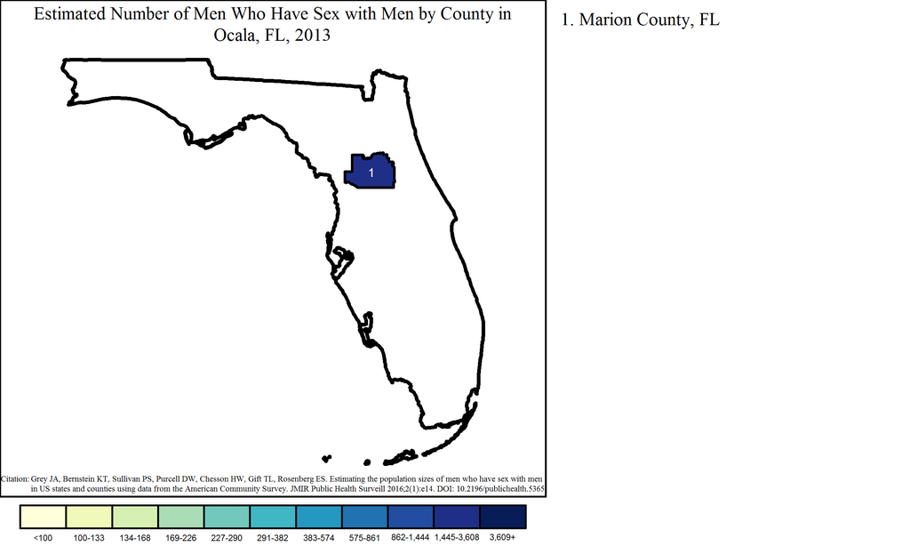

Note: Range cutpoints for the map are based on the distribution of MSM among all counties in the United States.

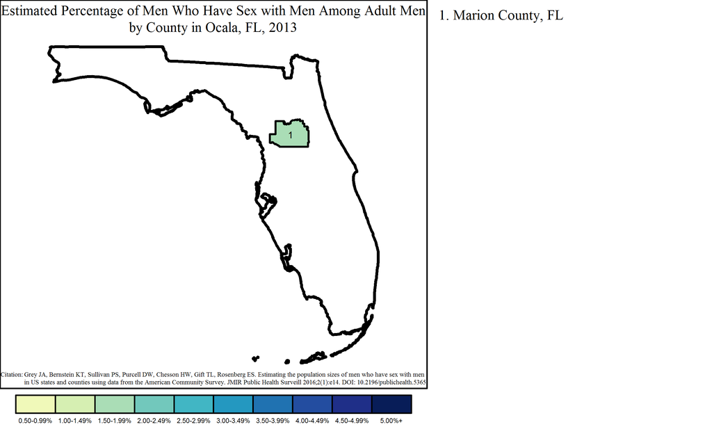

#### Crestview-Fort Walton Beach-Destin Metropolitan Statistical Area

The Crestview-Fort Walton Beach-Destin MSA had a population of 1,681 MSM, or 0.5% of all MSM in Florida. Of the 95,534 adult men in Crestview-Fort Walton Beach-Destin, an estimated 1.8% were MSM.

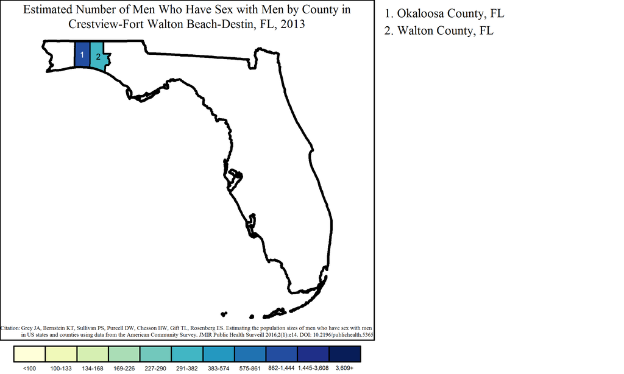

Note: Range cutpoints for the map are based on the distribution of MSM among all counties in the United States.

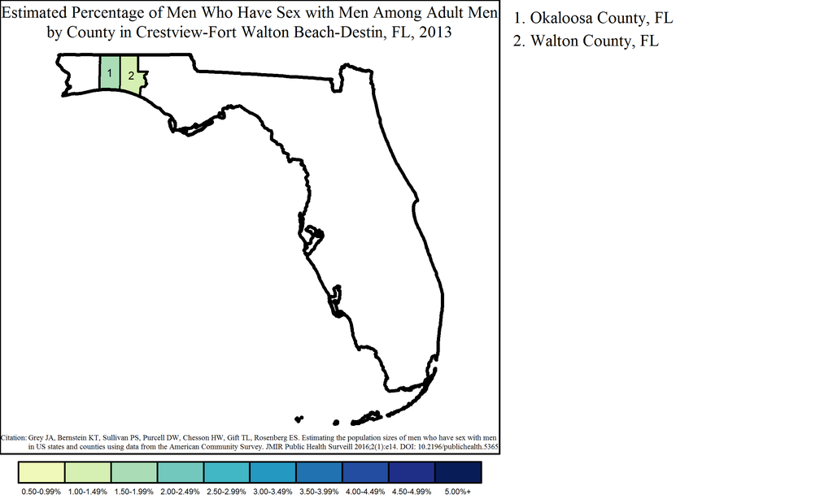

#### Sebastian-Vero Beach Metropolitan Statistical Area

The Sebastian-Vero Beach MSA had a population of 1,648 MSM, or 0.5% of all MSM in Florida. Of the 53,996 adult men in Sebastian-Vero Beach, an estimated 3.1% were MSM.

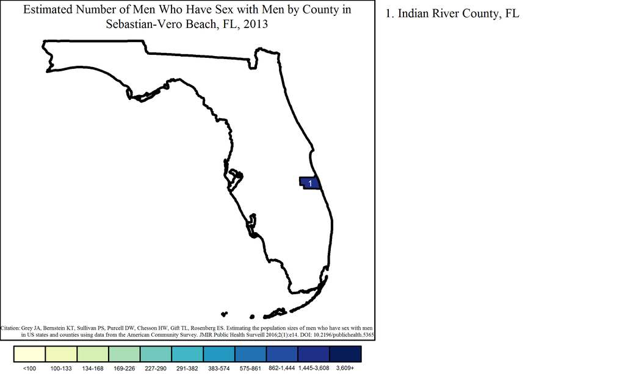

Note: Range cutpoints for the map are based on the distribution of MSM among all counties in the United States.

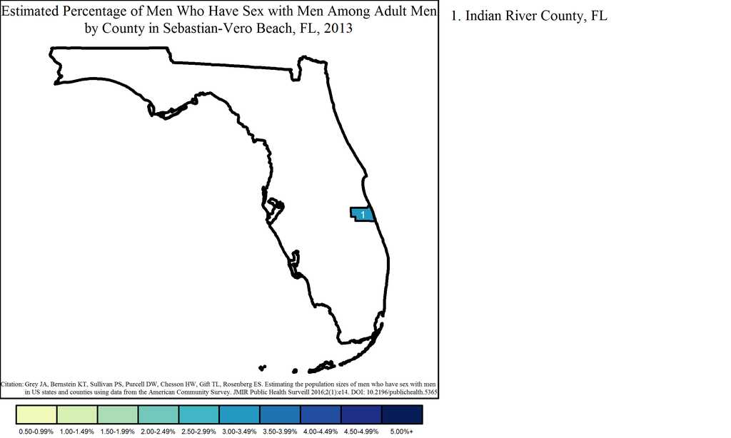

#### Punta Gorda Metropolitan Statistical Area

The Punta Gorda MSA had a population of 1,610 MSM, or 0.5% of all MSM in Florida. Of the 66,758 adult men in Punta Gorda, an estimated 2.4% were MSM.

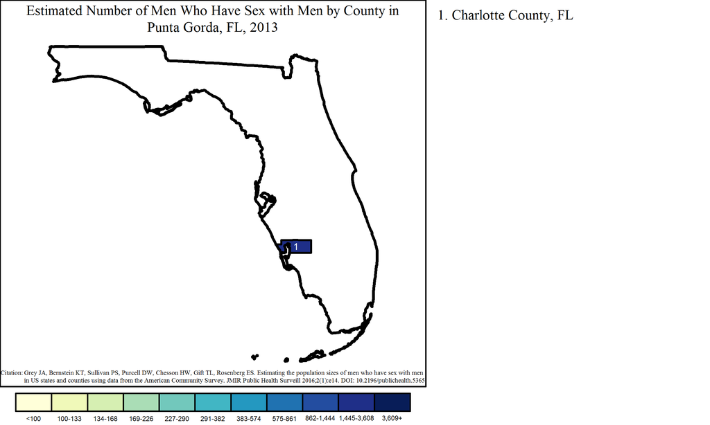

Note: Range cutpoints for the map are based on the distribution of MSM among all counties in the United States.

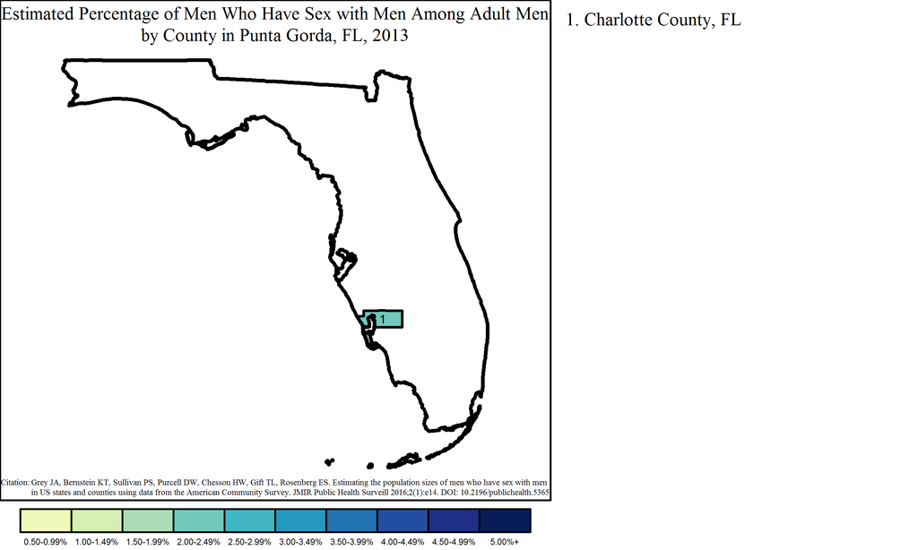

#### Panama City Metropolitan Statistical Area

The Panama City MSA had a population of 1,565 MSM, or 0.5% of all MSM in Florida. Of the 73,343 adult men in Panama City, an estimated 2.1% were MSM.

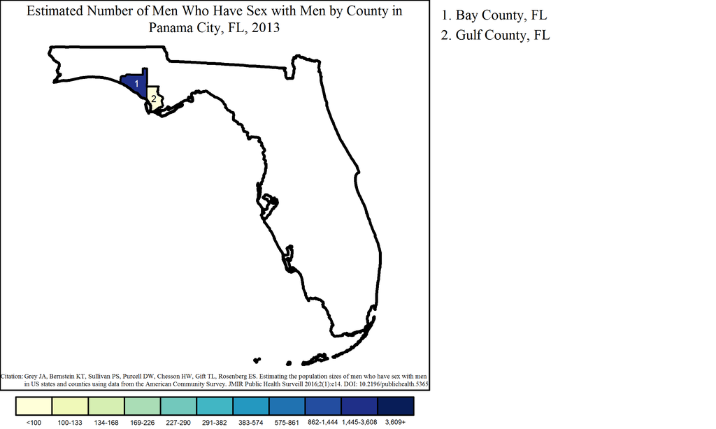

Note: Range cutpoints for the map are based on the distribution of MSM among all counties in the United States.

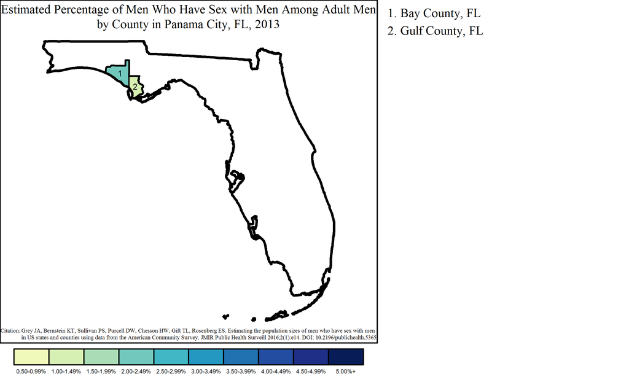

#### Sebring Metropolitan Statistical Area

The Sebring MSA had a population of 1,198 MSM, or 0.4% of all MSM in Florida. Of the 38,820 adult men in Sebring, an estimated 3.1% were MSM.

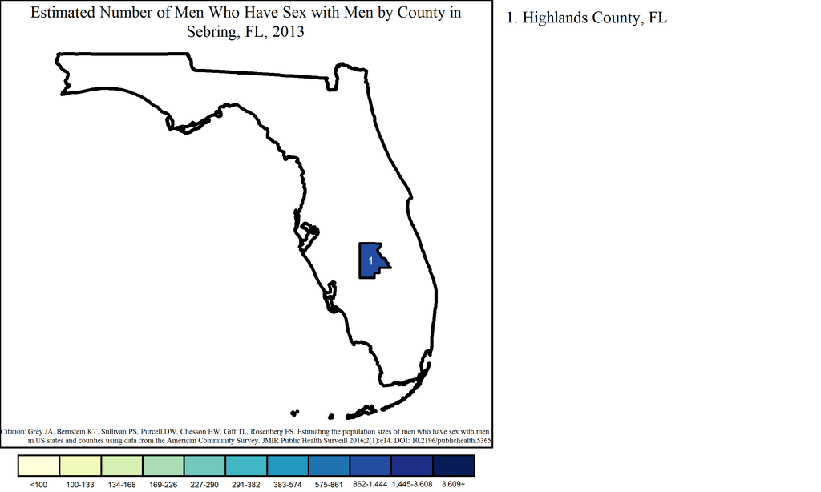

Note: Range cutpoints for the map are based on the distribution of MSM among all counties in the United States.

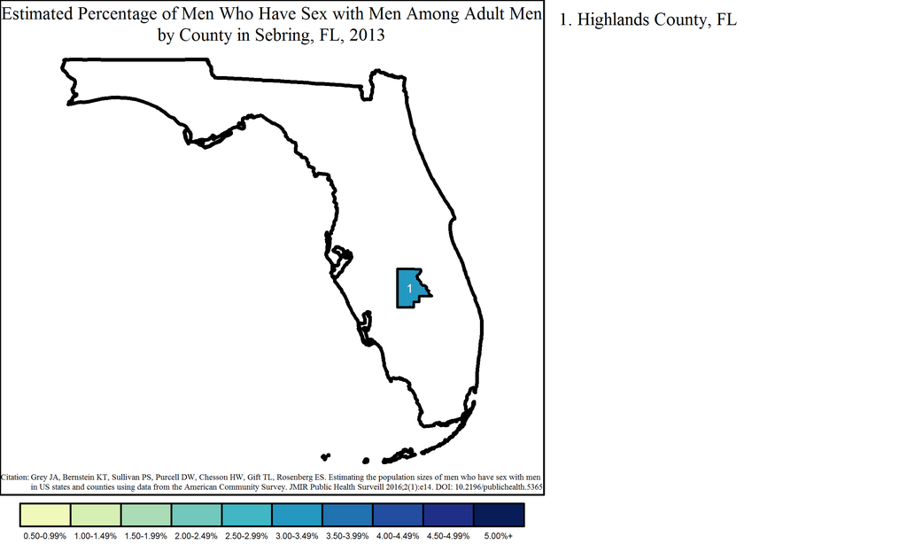

#### The Villages Metropolitan Statistical Area

The The Villages MSA had a population of 1,157 MSM, or 0.3% of all MSM in Florida. Of the 46,494 adult men in The Villages, an estimated 2.5% were MSM.

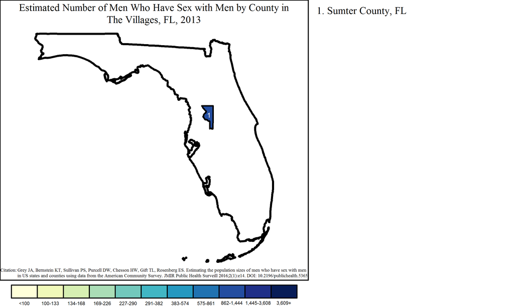

Note: Range cutpoints for the map are based on the distribution of MSM among all counties in the United States.

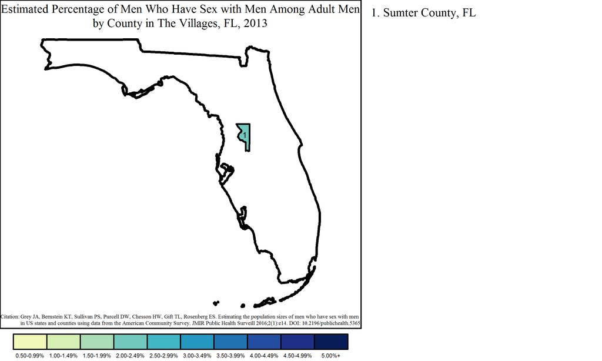

#### Homosassa Springs Metropolitan Statistical Area

The Homosassa Springs MSA had a population of 932 MSM, or 0.3% of all MSM in Florida. Of the 56,776 adult men in Homosassa Springs, an estimated 1.6% were MSM.

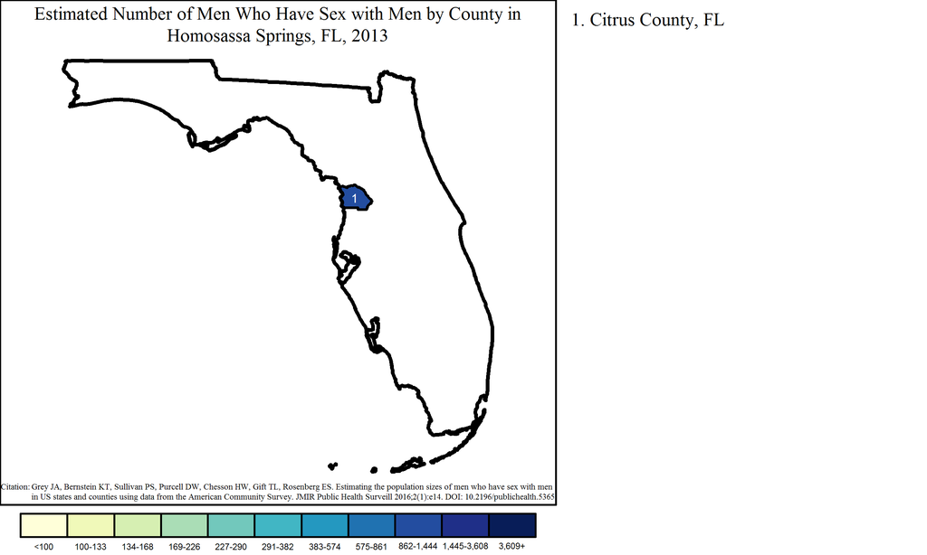

Note: Range cutpoints for the map are based on the distribution of MSM among all counties in the United States.

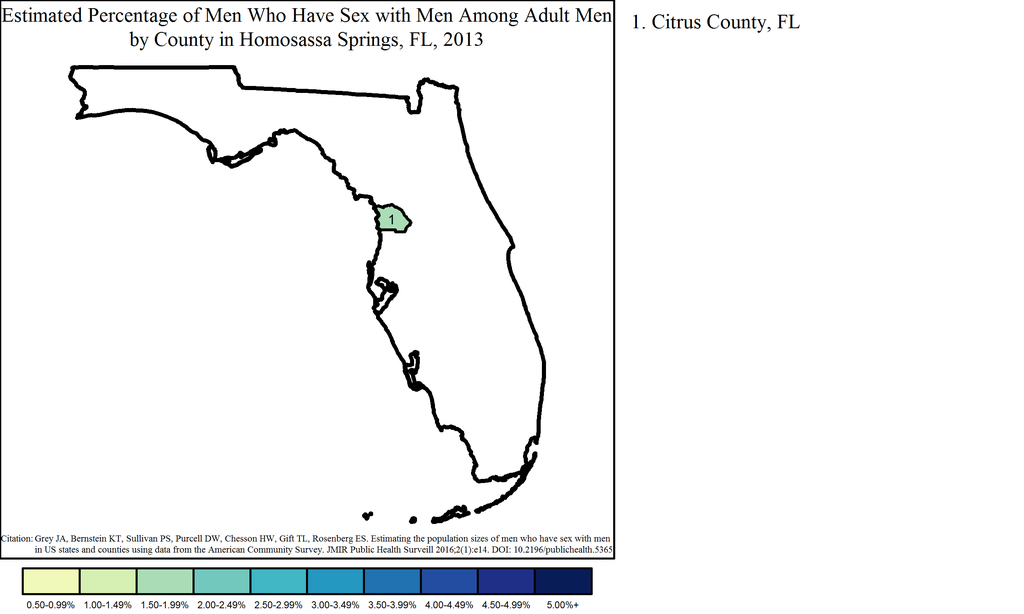